# Stat 6021: Project 1

Group 2: Ben G. Ballard, Sirish Kumar Desai, Kevin Kuc, Tom Lever

10/01/22

# Executive Summary

Blue Nile, Inc. contacted our team of data analysts to review a data set containing data relating to $1214$ various diamonds for sale on Blue Nile’s website. Our team was tasked with exploring the relationships between key attributes of the diamonds: weight (carat); clarity; color; cut; and price. Below, we further describe these data and variables and present visualizations and analysis. Our visualizations illustrate proportions of diamonds across groups of variables. Our analysis describes trends within the visualizations and evaluates claims on Blue Nile’s website.

Color is the second most significant factor that influences the price of a diamond. As the diamond becomes more colorful the diamond generally decreases in value. The Gemological Institute of America (GIA) color scale is the industry standard for diamond grading. The scale starts with $D$ for least colorful diamonds and alphabetically proceeds to $Z$ for most colorful diamonds (although Blue Nile only carries diamonds with color identifiers in the range $D$ through $J$).

The weight of a diamond is measured in carats; Blue Nile and others refer to the weight of a diamond as carat weight and carat. The weight of a diamond is not always indicative of a diamond’s size. That being said, we found that as weight increases, the price of a diamond also increases, at an increasing rate, with increasing variability. In “Simple Linear Regression of Price versus Weight”, we determine a linear model that relates transformed price to transformed weight. This linear model may be used to predict diamond price given weight. For an increase in weight of $10$ percent, price increases by a factor of $1.2$. For example, for an increase in weight from $1 \ carat$ to $1.1 \ carat$, price increases from $\$5,019.07$ by a factor of $1.2$ to $\$6,040.75$. These prices have a ratio of $1.2$.

Overall, the cut, color, clarity, and carat of a diamond are all predictors for a diamond’s market value, with various qualifications.

# Presentation and Analysis of Data

## Description of Data and Variables

Our data set describes $1214$ difference diamonds that are for sale at http://www.bluenile.com. Our data set describes diamonds with carat, clarity, color, cut, and price data. Our data set describes a subset of the diamonds that are for sale with a subset of features. Table 1 presents data for three diamonds.

first three diamonds in our data set

| weight | clarity | color | cut | price |
| --- | --- | --- | --- | --- |
| 0.51 | SI2 | I | Very Good | 774 |
| 0.93 | IF | H | Ideal | 6246 |
| 0.50 | VVS2 | D | Very Good | 1146 |

Weight measures a diamond’s weight in carats. Clarity assesses small imperfections within a diamond and quantifies and specifies inclusions. Color refers to how colorless a diamond is. Cut measures how well-proportioned a diamond’s dimensions are.

## General Analysis, and Visualizations and Visualization-Specific Analysis

### General Analysis

Ben:

This report explores the relationships between key attributes of the diamonds, specifically, carat, clarity, color, cut, and finally price. Price is the attribute we are most interested in. We are interested in the other attributes in as far as they can be used to evaluate price. We first explored the relationship of the attributes, or variables, by exploring one variable at a time, known as univariate analysis. Then we explored relationships between two or more variables at a time, known as multivariate analysis. We did this through data visualization and descriptive statistics.

We start by analyzing the data systematically, one variable at a time, through data visualization. As the saying goes, a picture is worth a thousand words. An effective graphic can quickly communicate a lot about a dataset’s describe statistics. Common univariate data visualizations graphics are histograms, density plots, and boxplots. These visualizations show the count or proportion of the variable in question as well as the dispersion or spread of the data. We use multivariate graphics to quickly understand the relationship of two or more variables. Common data visualizations include scatterplots, boxplots, and histograms.

We identified high-level findings relating to cut, color, clarity, and weight and their relationships to price. In some attributes, characteristics clearly had higher prices. However, in some attributes, the way those attributes related to price was less obvious. For example, within Clarity, there is a designation ‘FL’ that has much higher prices than any other clarity designation. Whereas some attributes, such as Color, one color attribute does not stand out as having a higher price than the others.

Sirish:

Considering the claim that “The higher [in weight] a diamond is, the more expensive it will be,” we find in a scatterplot of price versus weight a trend that s weight of a diamond increases, price of the diamond increases, at an increasing rate.

### Detailed Visualizations and Plot-Specific Analysis

Considering proportions of diamonds by clarity, the group of diamonds with clarity identifier $SI1$ has the highest proportion of about $0.2$. For a transition from a group of diamonds with a clarity identifier in the set {$VS1$, $VVS2$, $VVS1$, $IF$, $FL$} to a group of diamonds with clarity identifier closer to $FL$, proportion of diamonds decreases. The group of diamonds with clarity identifier $FL$ has the lowest proportion of less than $0.01$.

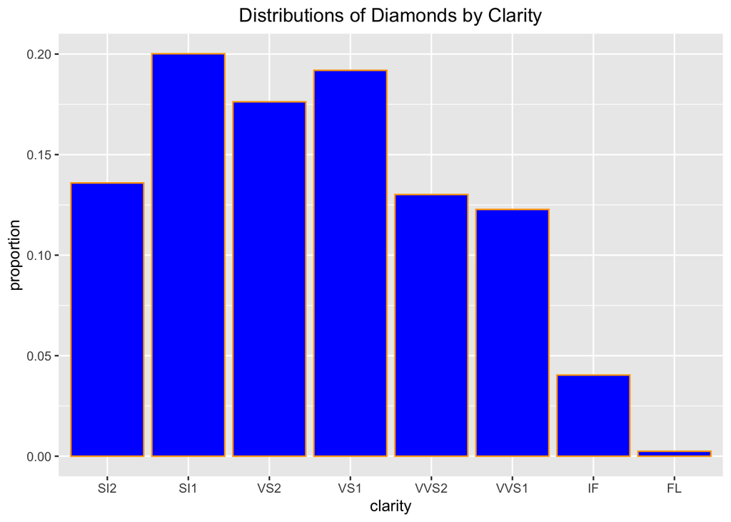

Considering proportions of diamonds by color, the group of diamonds with color identifier $F$ has the highest proportion of over $0.175$. The group of diamonds with color identifier $J$ has the lowest proportion of about $0.075$. There seems to be a general trend of proportion increasing as color identifier approaches $D$.

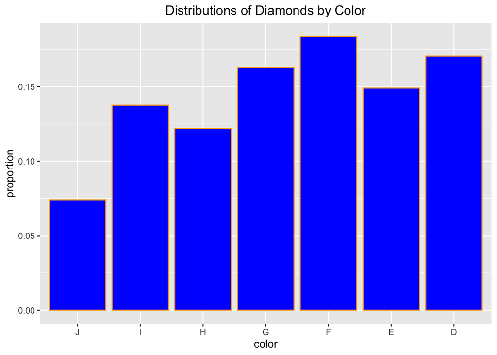

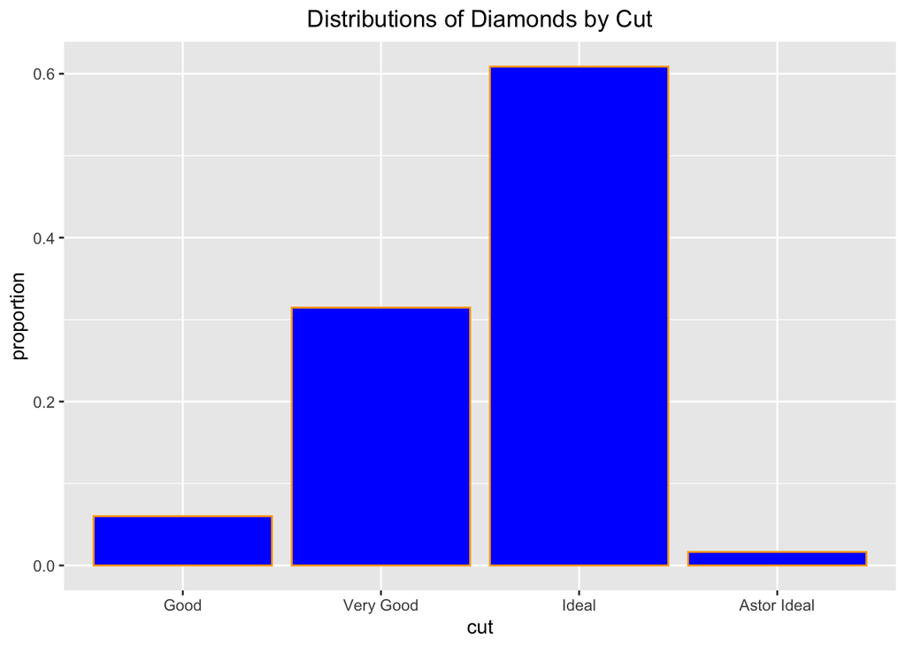

Considering a boxplot and a probability density distribution for weight, the middle $50$ percent of weights fall between about $0.4 \ carat$ and $1.0 \ carat$. The distribution is non-normal and positively / right skewed.

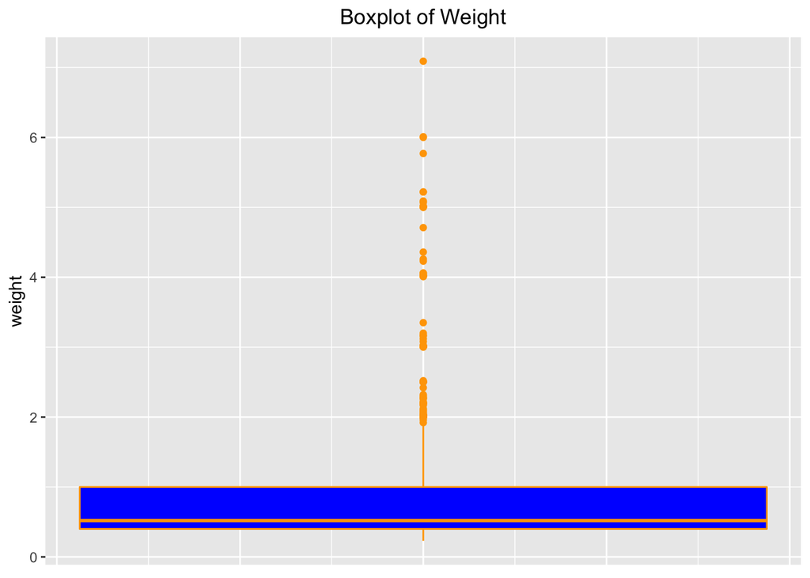

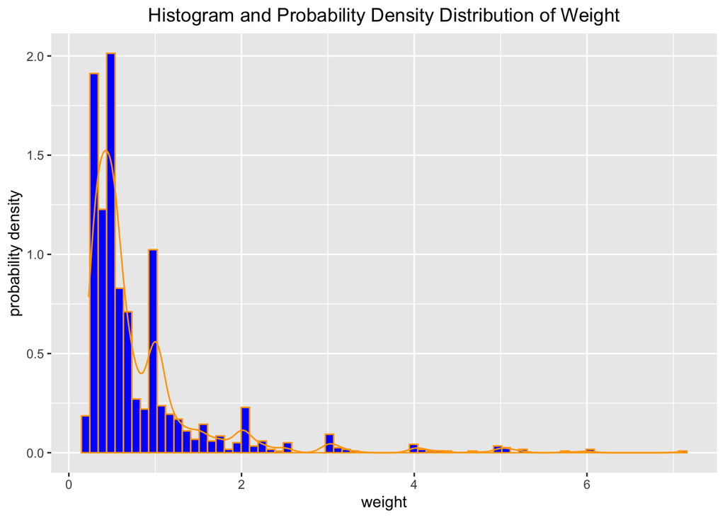

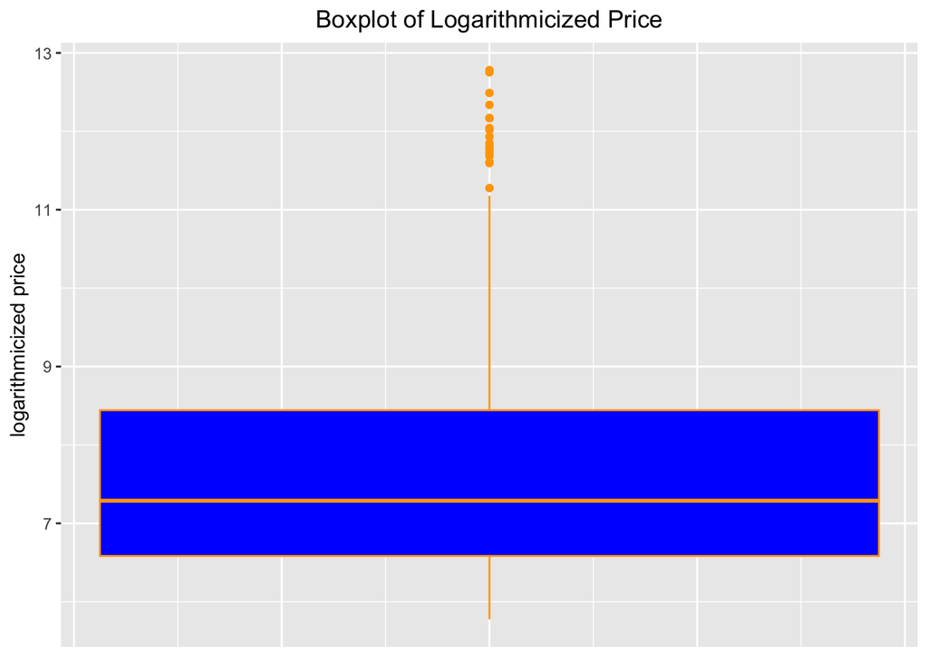

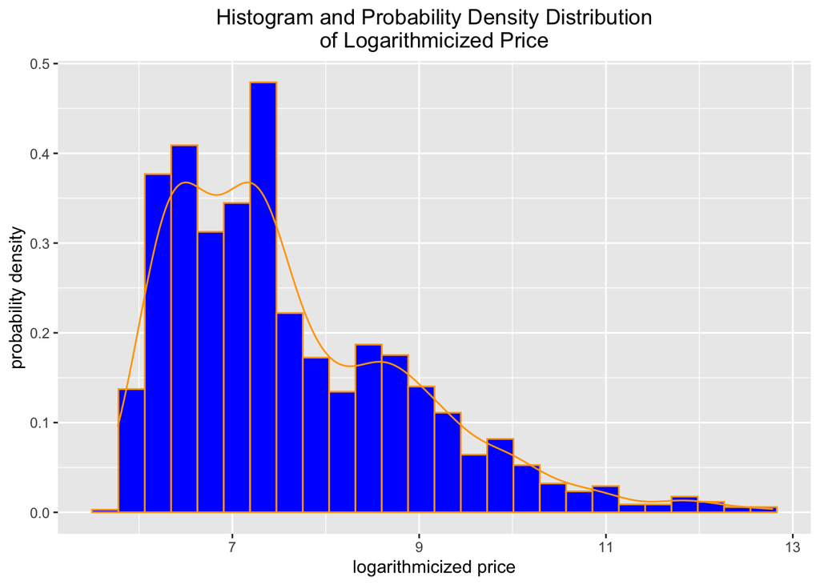

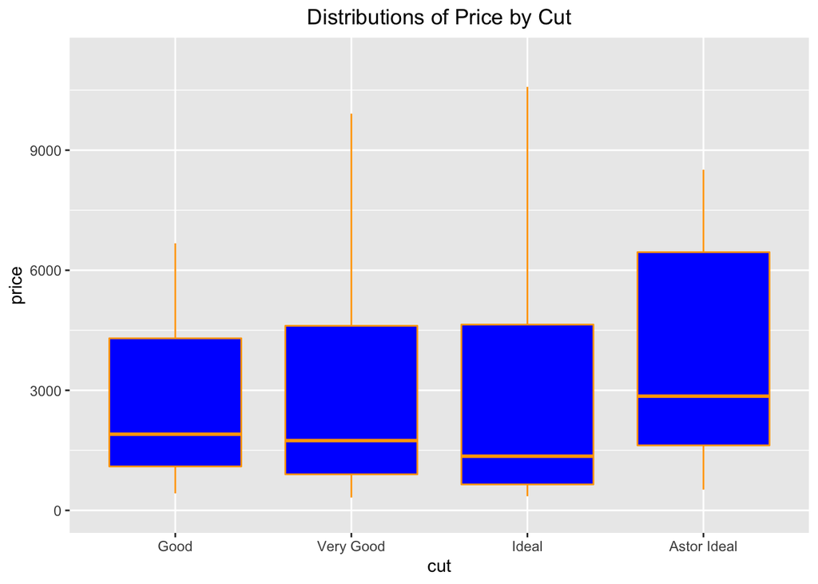

Considering the relationship of price of a diamond in our data set and the color of the diamond, we construct boxplots of price versus color with and without outliers and present the boxplot without outliers. Including outliers, for a transition from a group of diamonds with a color identifier in the English alphabet to a group of diamonds with a color identifier of the next letter closer to the beginning of the alphabet, maximum price of a diamond increases from around $\$50,000$ to around $\$350,000$. Excluding outliers, a group of diamonds with color identifier $H$ has the highest price of about $\$13,750$ and the highest interquartile range of prices. A diamond with color identifier $D$ has the lowest price of $\$322$. For a transition from a group of diamonds with a color identifier $G$ to a group of diamonds with a color identifier of a letter closer to the beginning of the alphabet, the first-quartile / median / third-quartile price of a diamond increases.

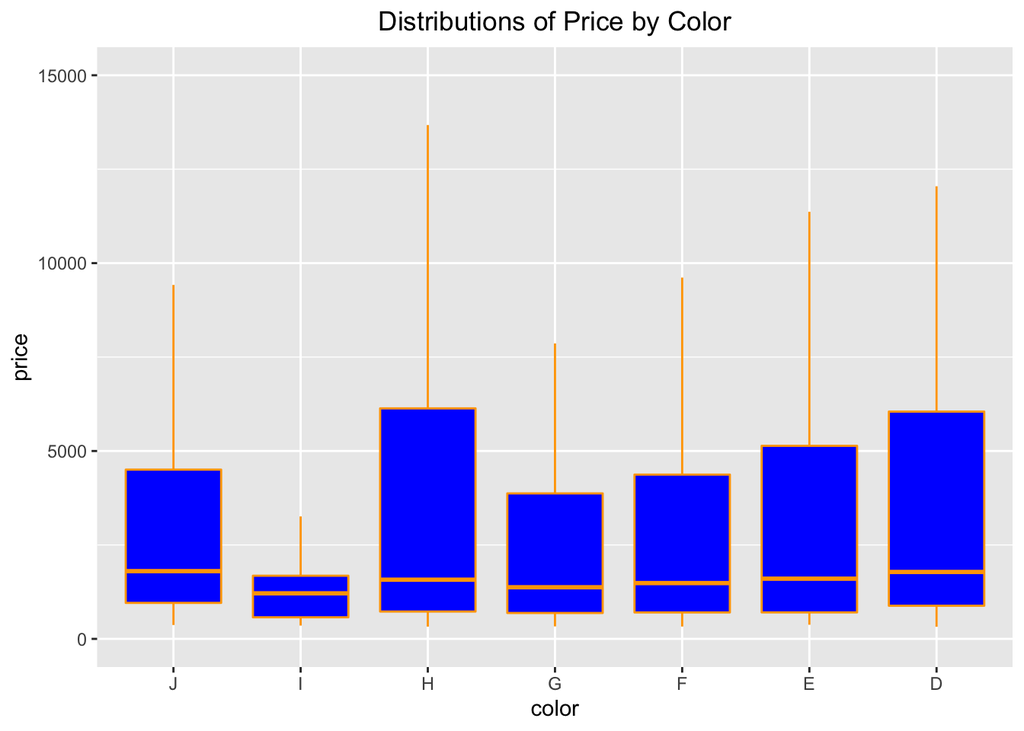

Considering the relationship of price of a diamond in our data set and the clarity of the diamond, we construct boxplots of price versus clarity with outliers and group of diamonds with clarity identifier $FL$, and without outliers and without the group of diamonds with clarity identifier $FL$. Including outliers and the group of diamonds with clarity identifier $FL$, a diamond with clarity identifier $FL$ has the highest first-quartile / median / third-quartile / maximum price and interquartile range of prices. Excluding outliers and the group of diamonds with clarity identifier $FL$, a diamond with clarity identifier $VS1$ has the lowest price. A diamond with clarity identifier $VS1$ has the highest first-quartile / third-quartile / maximum price and interquartile range of prices. A diamond with clarity identifier $SI1$ has the highest median price.

Considering the claim at https://www.bluenile.com/education/diamonds that “The higher [in clarity] a diamond is, the more expensive it will be”, this claim is supported in that flawless diamonds have the highest first-quartile / median / third-quartile / maximum price. However, neither when including nor excluding outliers is this claim supported by a trend that price increases with clarity.

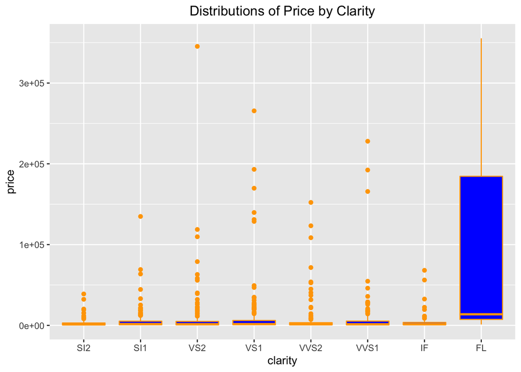

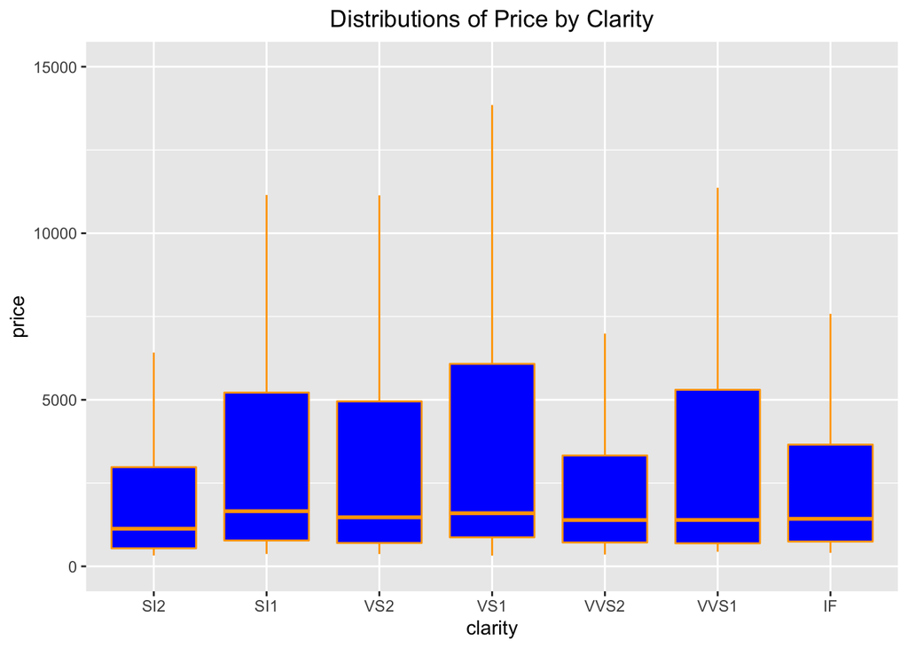

Considering the relationship of weight of a diamond in our data set and the cut of the diamond, we construct a boxplot of weight versus cut. Including outliers, an ideal diamond has the highest weight of over $5 \ carat$. Excluding outliers, an ideal diamond the highest weight of about $2 \ carat$. An Astor ideal diamond has the lowest weight of $0.23 \ carat$. Astor ideal diamonds have the highest first-quartile, median, and third-quartile weights. Ideal diamonds have the greatest interquartile range of weights. The median weights of good, very good, and ideal diamonds decrease in that order.

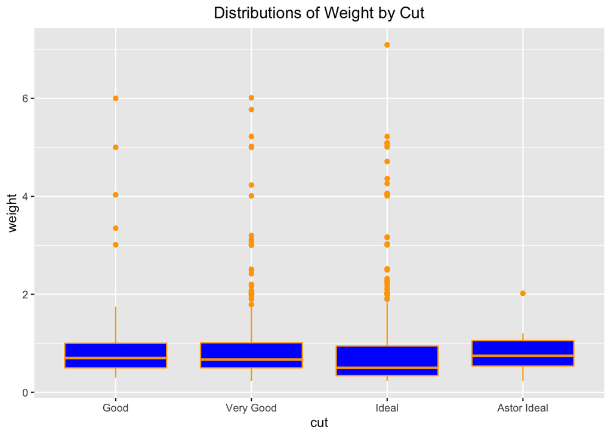

Considering the relationship of weight of a diamond in our data set and the color of the diamond, we construct a boxplot of weight versus color. Including outliers, a diamond with color identifier $E$ has the highest weight of over $7 \ carat$. Excluding outliers, a diamond with color identifier $F$ or $E$ has the highest weight of around $2 \ carat$. A diamond with color identifier $F$ has the lowest weight of $0.23 \ carat$.

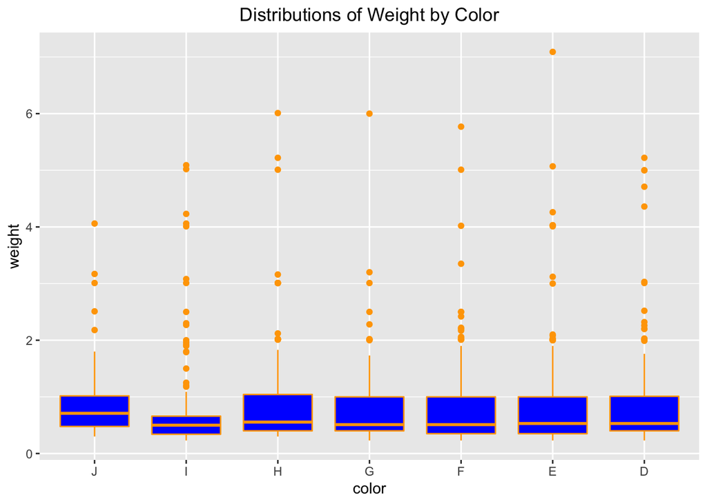

Considering the relationship of weight of a diamond in our data set and the clarity of the diamond, we construct a boxplot of weight versus color. Including outliers, a diamond with clarity identifier $VS2$ has the highest weight of over $7 \ carat$. Excluding outliers, a diamond with clarity identifier $FL$ has the highest weight over about $5.3 \ carat$. A diamond with clarity identifier $VS1$ has the lowest weight of $0.23 \ carat$. Diamonds with clarity identifier $FL$ have the highest first-quartile / median / third-quartile weights.

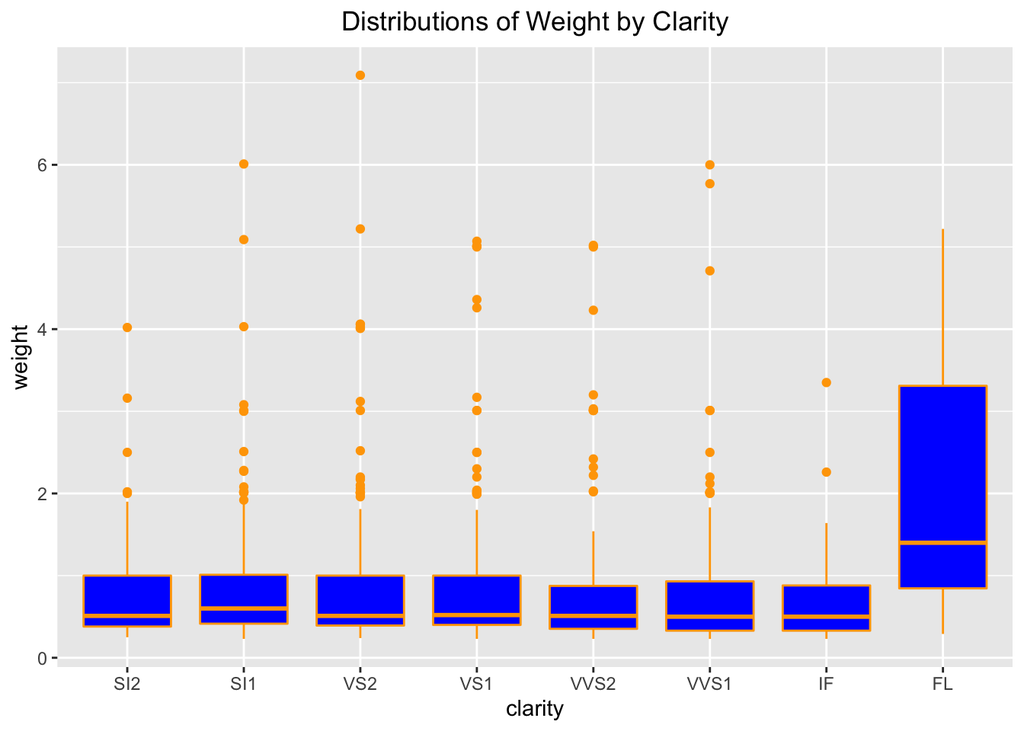

```
## [1] VS1
## Levels: SI2 SI1 VS2 VS1 VVS2 VVS1 IF FL
```

Considering the relationship of cut of a diamond in our data set and the color of the diamond, we construct a bar chart of proportion of cut by color. For each group of diamonds with a unique color identifier, most diamonds were ideal. The proportions of ideal, very good, good, and Astor ideal diamonds decreased in that order. The group of diamonds with color identifier $F$ had the highest proportion of Astor ideal diamonds. The group of diamonds with color identifier $I$ had the highest proportion of ideal diamonds. The group of diamonds with color identifier $G$ had the highest proportion of very good diamonds. The group of diamonds with color identifier $D$ had the highest proportion of good diamonds.

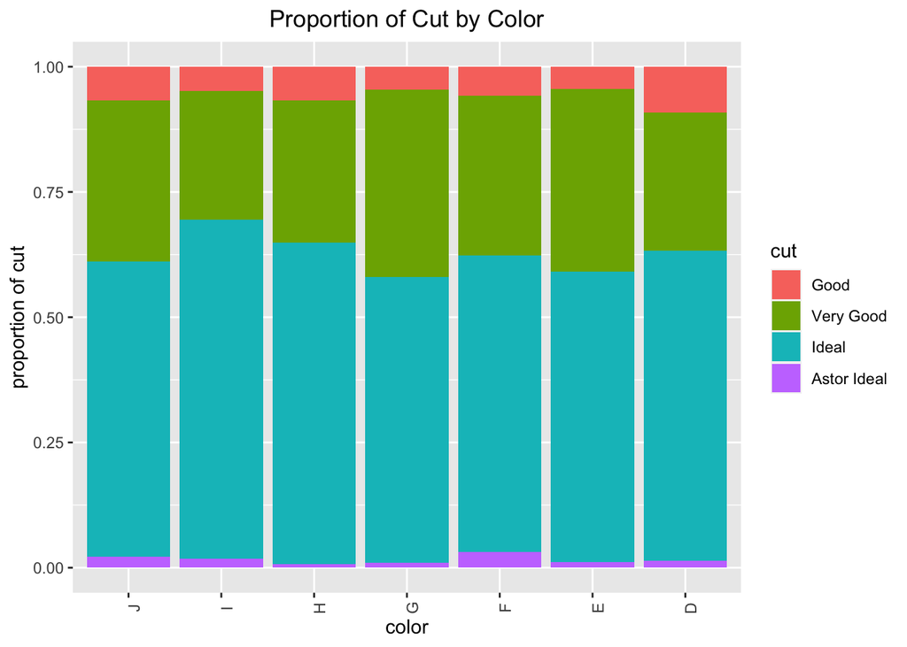

Considering the relationship of cut of a diamond in our data set and the clarity of the diamond, we construct a bar chart of proportion of cut by clarity. For a group of diamonds with a clarity identifier other than $FL$, most diamonds are ideal. For a transition from a group of diamonds with a clarity identifier in the set of identifiers {$VS1$, $VVS2$, $VVS1$, $IF$} to a group of diamonds with a clarity identifier in that set closer to $IF$, the proportion of ideal diamonds increases and the proportion of very good diamonds decreases, and the proportion of Astor ideal diamonds decreases. For a transition from a group of diamonds with a clarity identifier in the set of identifiers {$SI2$, $SI1$, $VS2$, $VS1$, $VVS1$} to a group of diamonds with a clarity identifier in that set closer to $VVS1$, the proportion of good diamonds decreases. The majority of diamonds with clarity identifier $FL$ are very good, while all other diamonds with clarity identifier $FL$ are ideal.

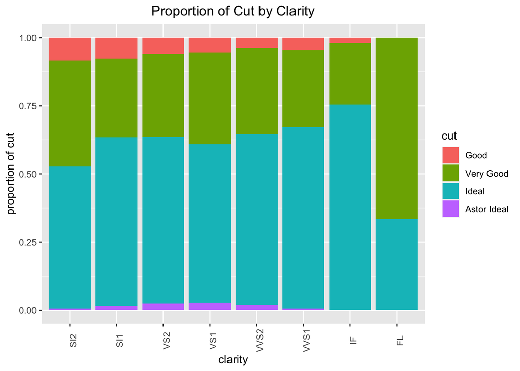

Considering the relationship of color of a diamond in our data set and the clarity of the diamond, we construct a bar chart of proportion of color by clarity. The proportion of diamonds with color identifier $D$ for the group of diamonds with clarity identifier $FL$ is greater than $0.5$, is the only proportion greater than $0.5$, and is significantly greater than the proportion of diamonds with color identifier $D$ for any other group of diamonds by clarity identifier. For the group of diamonds with clarity identifier $FL$, all diamonds other than diamonds with color identifier $D$ have color identifier $F$. For a transition from a group of diamonds with a clarity identifier in the set of identifiers {$VVS2$, $VVS1$, $IF$, $FL$} to a group of diamonds with a clarity identifier in that set closer to $FL$, the proportion of diamonds with color identifier $F$ increases.

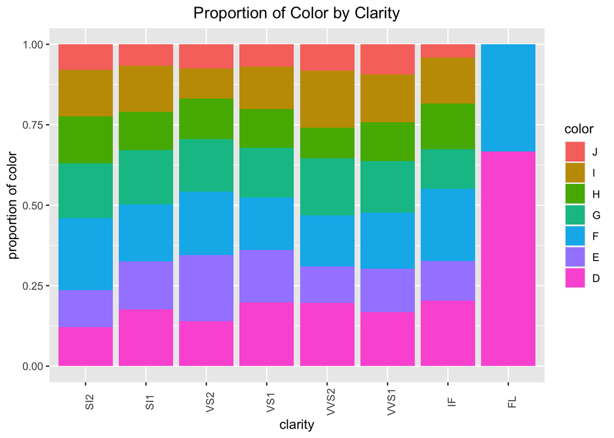

Considering the relationship of price of a diamond in our data set and the weight of the diamond, we construct a scatterplot for a linear model of price versus weight, as well as a plot of externally studentized residuals versus predicted prices for the model, a plot of AutoCorrelation Function values versus lag for the model, and a plot of sample quantiles versus theoretical quantiles for the residuals of the model.

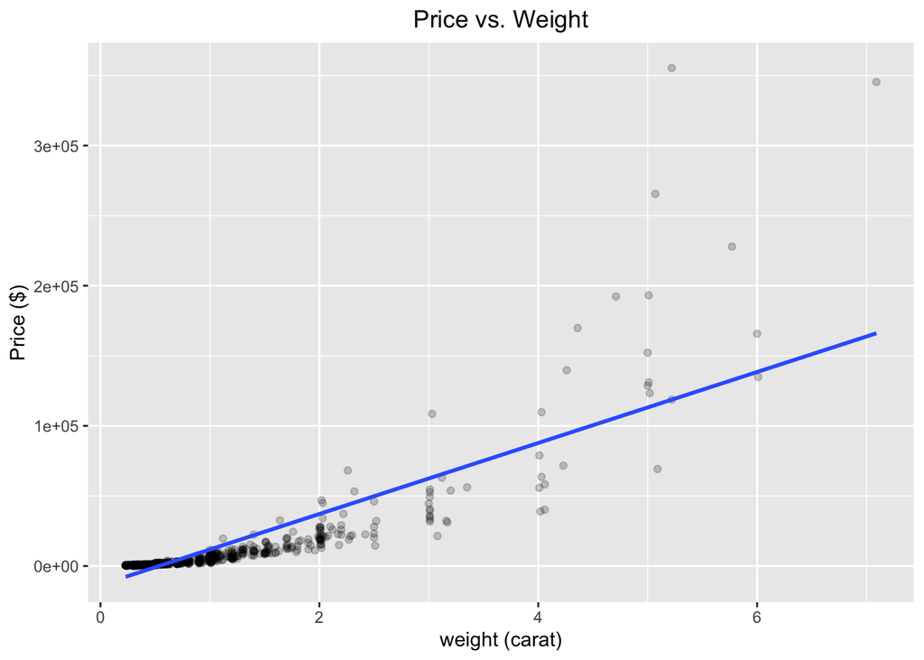

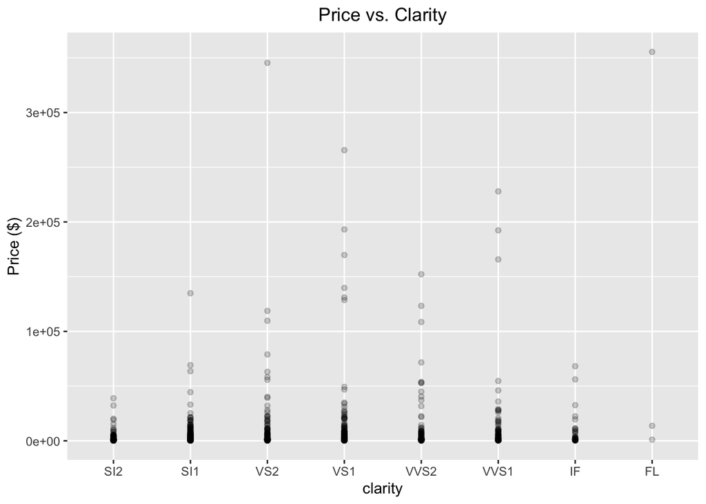

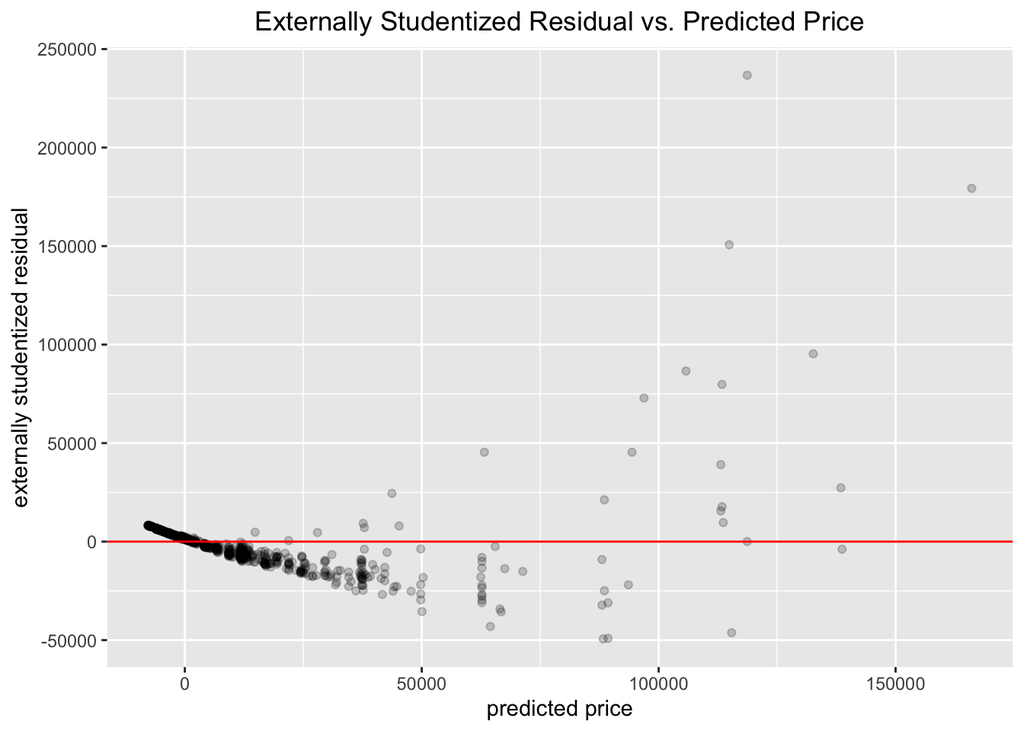

[figure not shown]

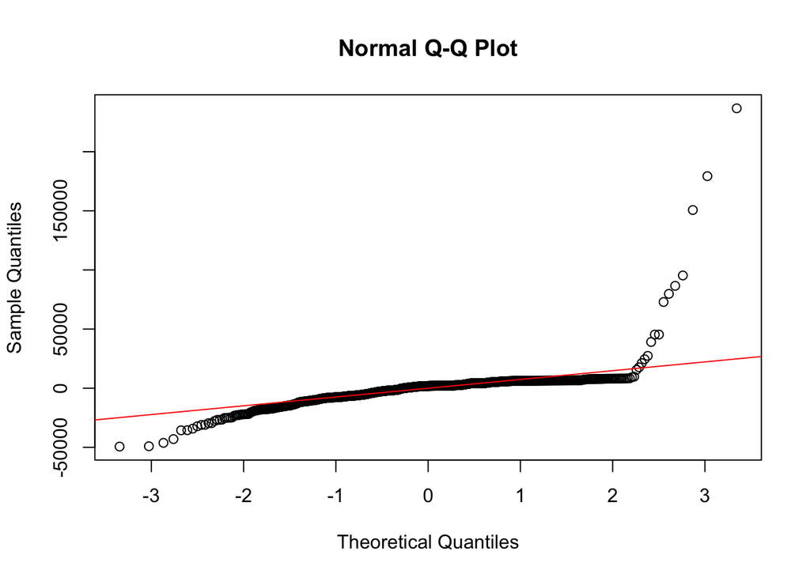

# Simple Linear Regression of Price versus Weight

Simple linear regression depends of the following five assumptions being met.

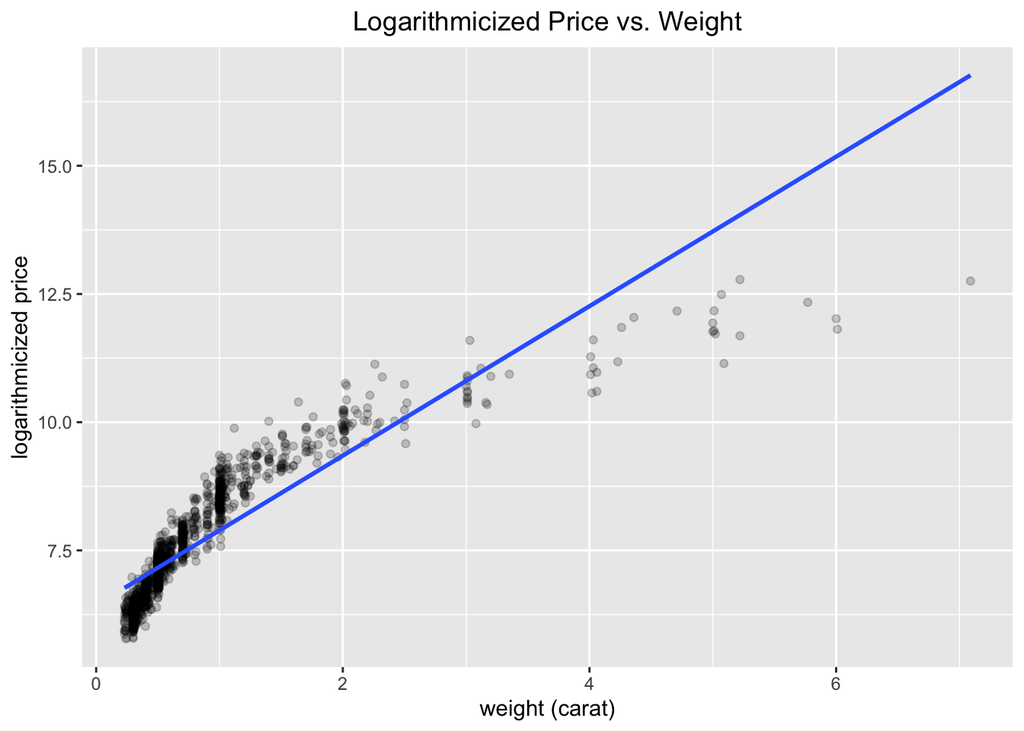

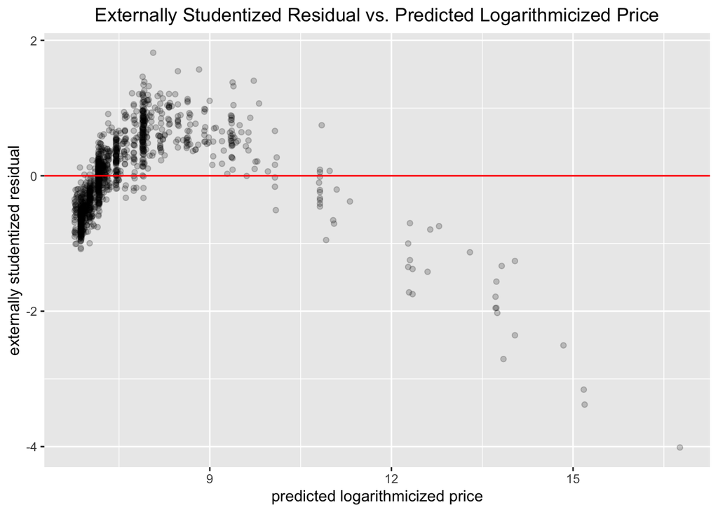

We have generated a data set of logarithmicized price versus weight for which the assumption that the distributions of residuals of a linear model of logarithmicized price and/or weight for different weights have constant variance. To generate a data set of transformed price and/or transformed weight for which the assumption that the relationship between transformed price and/or transformed weight is linear is met, and the assumption that the mean of the residuals of the linear model of transformed price and/or transformed weight is $0$, we take our logarithmicized-price data and additionally logarithmicize weight. We present a scatterplot of logarithmicized price versus logarithmicized weight. We construct a linear model of logarithmicized price versus logarithmicized weight. We present a scatterplot of externally studentized residuals versus predicted logarithmicized price for the linear model of logarithmicized price versus logarithmicized weight. Additionally, we construct a plot of AutoCorrelation Function values versus lag for the linear model, and a plot of sample quantiles versus theoretical quantiles for the residuals of the model.

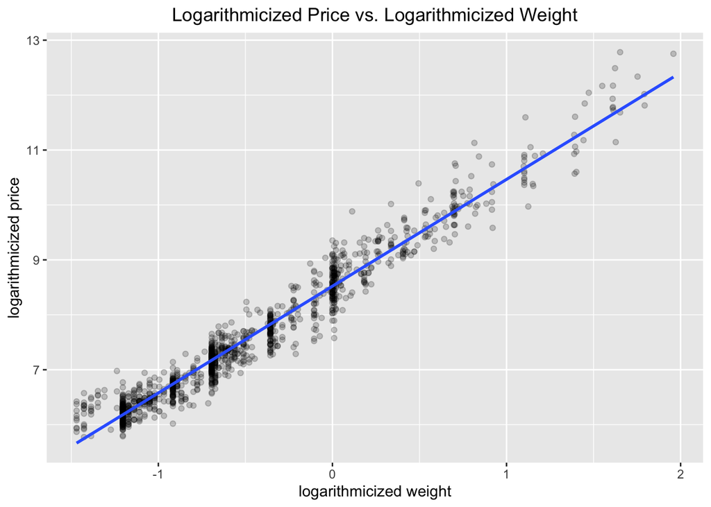

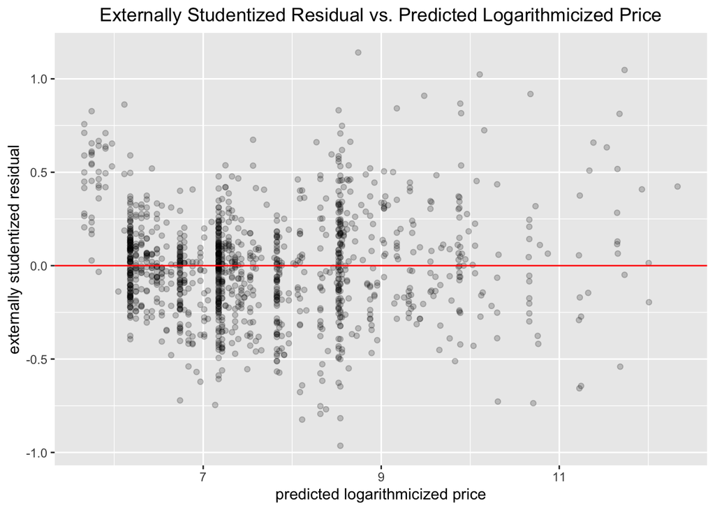

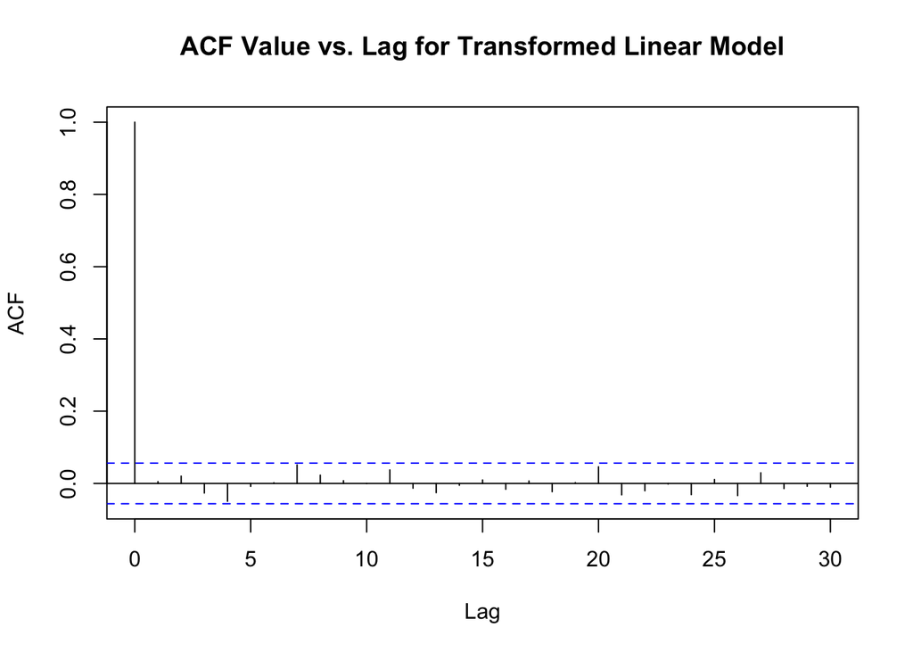

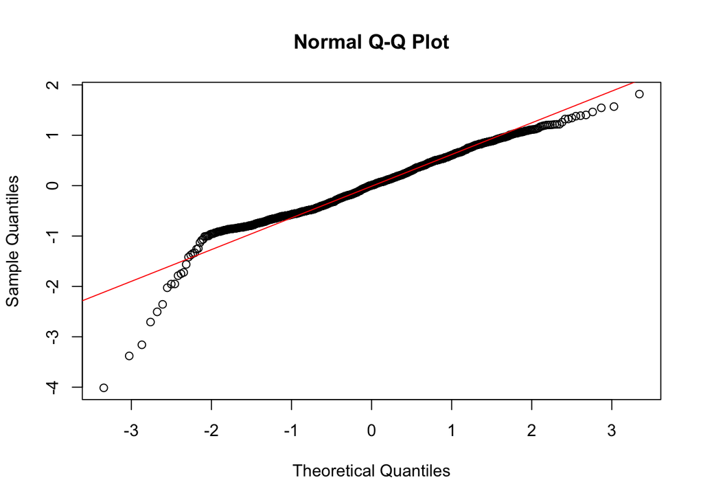

1. The assumption that the relationship between response / logarithmicized price and predictor / regressor / logarithmicized weight is linear, at least approximately, is met. The relationship appears to be linear.
2. The assumption that the residuals of the linear model of logarithmicized price versus logarithmicized weight have mean $0$ is met. observations are scattered evenly around the fitted line. Residuals are evenly scattered around $e = 0$.
3. The assumptions that the distributions of residuals of the linear model of logarithmicized price versus logarithmized weight for different weights have constant variance is met. The vertical variation of observations is constant. Residuals are evenly scattered around $e = 0$.
4. The assumption that the residuals of the linear model of logarithmicized price versus logarithmicized weight are uncorrelated is met. The ACF value for lag $0$ is always $1$; the correlation of the vector of residuals with itself is always 1. Since all ACF value are insignificant, we have insufficient evidence to reject a null hypothesis that the residuals of the linear model of logarithmicized price versus logarithmicized weight are uncorrelated. We have insufficient evidence to conclude that the residuals of the linear model of logarithmicized price versus logarithmicized weight are correlated. We have insufficient evidence to conclude that the assumption that the residuals of the linear model of logarithmicized price versus logarithmicized weight are uncorrelated is not met.
5. The assumption that the residuals of the linear model of logarithmicized price versus logarithmicized weight are normally distributed is not met. However, a linear model is robust to these assumptions. Given a sharp downward curve at the bottom left of a plot of sample quantiles versus theoretical quantiles for the residuals of the linear model of logarithmicized price versus logarithmicized weight, a probability vs. externally studentized residuals plot / distribution is not normal.

We determine an estimated linear-regression equation
$$\hat{\beta}_0 = 8.521$$
$$\hat{\beta}_1 = 1.944$$
$$ln(\hat{y}) = \hat{\beta}_0 + \hat{\beta}_1
ln(x)$$
where $\hat{y} = E(y|x)$ is the expected price given a weight $x$.
$$\hat{y} =
exp[\hat{\beta}_0 + \hat{\beta}_1 ln(x)]$$
Consider weights $x$ and $x_+ = (1 + p) x$ and corresponding predicted prices $\hat{y}$ and $\hat{y}_+$.
$$ln(\hat{y}) = \hat{\beta}_0 + \hat{\beta}_1
ln(x)$$
$$ln\left(\hat{y}_+\right) =
\hat{\beta}_0 + \hat{\beta}_1 ln\left(x_+\right)$$
$$ln\left(\hat{y}_+\right) - ln\left(\hat{y}\right)
= \left[\hat{\beta}_0 + \hat{\beta}_1 ln\left(x_+\right)\right] -
\left[\hat{\beta}_0 + \hat{\beta}_1 ln\left(x\right)\right]$$
$$ln\left(\frac{\hat{y}_+}{\hat{y}}\right) =
\hat{\beta}_1 ln\left(x_+\right) - \hat{\beta}_1
ln\left(x\right)$$
$$ln\left(\frac{\hat{y}_+}{\hat{y}}\right) =
\hat{\beta}_1 \left[ln\left(x_+\right) -
ln\left(x\right)\right]$$
$$ln\left(\frac{\hat{y}_+}{\hat{y}}\right) =
\hat{\beta}_1 ln\left(\frac{x_+}{x}\right)$$
$$ln\left(\frac{\hat{y}_+}{\hat{y}}\right) =
\hat{\beta}_1 ln\left(\frac{(1 + p)x}{x}\right)$$
$$ln\left(\frac{\hat{y}_+}{\hat{y}}\right) =
\hat{\beta}_1 ln\left(1 + p\right)$$
$$ln\left(\frac{\hat{y}_+}{\hat{y}}\right) =
ln\left[\left(1 + p\right)^{\hat{\beta}_1}\right]$$
$$\frac{\hat{y}_+}{\hat{y}} = \left(1 +
p\right)^{\hat{\beta}_1}$$
For an increase in weight by proportion $p$, the predicted price increases by a factor of $(1 + p)^{\hat{\beta}_1}$. For example, for an increase in weight by proportion $0.1$, or $10$ percent, the predicted price increases by a factor of $(1 + 0.1)^{1.944} = 1.2$. For an increase in weight from $1 \ carat$ to $1.1 \ carat$, price increases from $exp\left[8.521 + 1.944 \ ln(1)\right] \ dollars = \$5,019.07$ by a factor of $1.2$ to $exp\left[8.521 + 1.944 \ ln(1.1)\right] \ dollars = \$6,040.75$. These prices have a ratio of $1.2$.